# BUDO-M ONTOLOGY and JSON-LD

When creating a JSON-LD file, it has to be defined the context. In this context, terms that will be used in the file are defined by referring to which ontology they belong.

In the case that the terms that are going to be used doesn't exist, an ontology has to be created in order to implement them. Thus, **BUDO-M** ontology has been created and is growing continuously as new terms are needed.

For this purpose, **Protégé** software: https://protege.stanford.edu/ can be used, where it is easy to load and existing ontology in several formats and add new classes or data properties. Afterwards, the ontology can be saved using the format that the user wants. It is recommended *Turtle format* because it is widely used and ontologies like **Brick schema** use it.

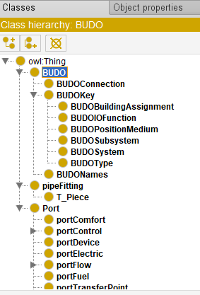

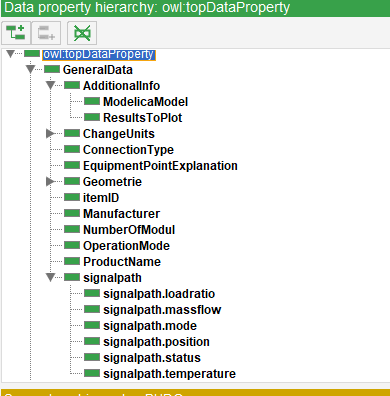

An snipped of the **BUDO-M.ttl** file downloaded from Protégé is shown below. Note that there has to be an URL that defines where the ontology is located, in this case: https://git.rwth-aachen.de/EBC/Team_BA/misc/Machine-Learning/tree/MA_fst-bll/building_ml_platform/BUDO-M/Platform_Application_AI_Buildings_MA_Llopis/OntologyToModelica/CoTeTo/ebc_jsonld#

```
@prefix : <https://git.rwth-aachen.de/EBC/Team_BA/misc/Machine-Learning/tree/MA_fst-bll/building_ml_platform/BUDO-M/Platform_Application_AI_Buildings_MA_Llopis/OntologyToModelica/CoTeTo/ebc_jsonld#> .
@prefix owl: <http://www.w3.org/2002/07/owl#> .
@prefix rdf: <http://www.w3.org/1999/02/22-rdf-syntax-ns#> .
@prefix xml: <http://www.w3.org/XML/1998/namespace> .
@prefix xsd: <http://www.w3.org/2001/XMLSchema#> .
@prefix rdfs: <http://www.w3.org/2000/01/rdf-schema#> .
@base <https://git.rwth-aachen.de/EBC/Team_BA/misc/Machine-Learning/tree/MA_fst-bll/building_ml_platform/BUDO-M/Platform_Application_AI_Buildings_MA_Llopis/OntologyToModelica/CoTeTo/ebc_jsonld> .

<https://git.rwth-aachen.de/EBC/Team_BA/misc/Machine-Learning/tree/MA_fst-bll/building_ml_platform/BUDO-M/Platform_Application_AI_Buildings_MA_Llopis/OntologyToModelica/CoTeTo/ebc_jsonld> rdf:type owl:Ontology .

#################################################################
#    Data properties
#################################################################

###  https://git.rwth-aachen.de/EBC/Team_BA/misc/Machine-Learning/tree/MA_fst-bll/building_ml_platform/BUDO-M/Platform_Application_AI_Buildings_MA_Llopis/OntologyToModelica/CoTeTo/ebc_jsonld#AdditionalInfo
:AdditionalInfo rdf:type owl:DatatypeProperty ;
                rdfs:subPropertyOf :GeneralData .


###  https://git.rwth-aachen.de/EBC/Team_BA/misc/Machine-Learning/tree/MA_fst-bll/building_ml_platform/BUDO-M/Platform_Application_AI_Buildings_MA_Llopis/OntologyToModelica/CoTeTo/ebc_jsonld#ChangeUnits
:ChangeUnits rdf:type owl:DatatypeProperty ;
             rdfs:subPropertyOf :GeneralData .


###  https://git.rwth-aachen.de/EBC/Team_BA/misc/Machine-Learning/tree/MA_fst-bll/building_ml_platform/BUDO-M/Platform_Application_AI_Buildings_MA_Llopis/OntologyToModelica/CoTeTo/ebc_jsonld#ConnectionType
:ConnectionType rdf:type owl:DatatypeProperty ;
                rdfs:subPropertyOf :GeneralData .
```

[...]

A normal and easy json-ld file can be the following one:

```
{
  "@context": "http://schema.org",
  "id": "http://www.wikidata.org/entity/Q76",
  "type": "Person",
  "name": "Barack Obama",
  "givenName": "Barack",
  "familyName": "Obama",
  "jobTitle": "44th President of the United States"
}
```

where the context is only composed by an ontology: **schema.org**, and all the terms of the file belong to this schema, so it is no needed to specify any more information.

In the case of needing different schemas, it has to be defined in the context the terms that will be used in the file and to which ontology they belong.

# JSON-LD and PYTHON

In order to use json-ld with Python, **PyLD** is the library for the implementation. It can be found here: https://github.com/digitalbazaar/pyld.

The way to write the JSON-LD differs a bit from the standard one, because it has to be separated the context from the rest of the file, and give them a name.

An example of a context that uses terms from different schemas like BUDO-M, BRICK or RDF can be seen below, where it is also written in the way that PyLD can read it. In the first lines it is defined the location of the ontologies used, and in the rest of the context the terms that will be used referring to the ontology to which they belong.

```
context = {
        "schema": "http://www.w3.org/2001/XMLSchema#",
        "brick": "http://brickschema.org/schema/1.0.3/Brick#",
        "brickFrame": "http://brickschema.org/schema/1.0.3/BrickFrame#",
        "BUDO-M": "https://git.rwth-aachen.de/EBC/Team_BA/misc/Machine-Learning/tree/MA_fst-bll/building_ml_platform/BUDO-M/Platform_Application_AI_Buildings_MA_Llopis/OntologyToModelica/CoTeTo/ebc_jsonld#",
        "rdf": "http://www.w3.org/1999/02/22-rdf-syntax-ns#",
        "rdfs": "http://www.w3.org/2000/01/rdf-schema#",

        "Zone": {"@id": "brick: HVAC Zone"},
        "TimeStart": {"@id": "schema: StartDate"},
        "TimeEnd": {"@id": "schema: EndDate"},
        "Point": {"@id": "brick: Point"},
        "BUDOKey": {"@id": "BUDO-M: BUDOKey"},
        "BUDOConnection": {"@id": "BUDO-M: BUDOConnection"},
        "ConnectionType": {"@id": "BUDO-M: ConnectionType"},
        "BUDOBuildingAssignment": {"@id": "BUDO-M: BUDOBuildingAssignment"},
        "BUDOSystem": {"@id": "BUDO-M: BUDOSystem"},
        "BUDOSubsystem": {"@id": "BUDO-M: BUDOSubsystem"},
        "BUDOPositionMedium": {"@id": "BUDO-M: BUDOPositionMedium"},
        "BUDOType": {"@id": "BUDO-M: BUDOType"},
        "BUDOIOFunction": {"@id": "BUDO-M: BUDOIOFunction"},
        "itemID": {"@id": "BUDO-M: ItemID"},
        "multiply": {"@id": "BUDO-M: multiply"},
        "plus": {"@id": "BUDO-M: plus"},
        "Equipment": {"@id": "brick: Equipment"},
        "hasPoint": {"@id": "brickFrame: hasPoint"},
        "ItemList": {"@id":"schema:ItemList"},
        "itemListElement": {"@id":"schema:itemListElement"},
        "Pump":  {"@id":"brick:Pump"},
        "Boiler":  {"@id":"brick:Boiler"},
        "Valve":  {"@id":"brick:Valve"},
        "Temperature_Sensor":  {"@id":"brick:Temperature_Sensor"},
        "Heat_Pump":  {"@id":"brick:Heat_Pump"},
        "Combined_Heat_Power":  {"@id":"brick:Combined_Heat_Power"},
        "Heat_Exchanger":  {"@id":"brick:Heat_Exchanger"},
        "Setpoint":  {"@id":"brick:Setpoint"},
        "Command":  {"@id":"brick:Command"},
        "Alarm":  {"@id":"brick:Alarm"},
        "Status":  {"@id":"brick:Status"},
        "T_Piece":  {"@id":"BUDO-M:T_Piece"},
        "BUDONames":  {"@id":"BUDO-M:BUDONames"}


}
```

The rest of the document can be written by using the terms already defined, where

```
"@context": context,
```

has to be specified, by writing the name of the context that has been given before (in this case "context").

Other interesating feature is the **ItemList** and **itemListElement** terms from schema ontology, that can be used to specify a list of elements.

In the following snipped of script it is shown how this is implemented.

```
doc = {

        "@context": context,
        "Zone":"K12",
        "TimeStart": "2016-07-09 00:00:00",
        "TimeEnd": "2016-07-16 00:00:00",

        "BUDOConnection":{
        "@type": "ItemList",
        "itemListElement": [
                       {

                        "Equipment": {
                            "BUDOBuildingAssignment": "BL-4120",
                            "BUDOSystem": "HP-K12",
                            "BUDOSubsystem": "M10"},

                        "ConnectionType": {"@type": "hasPoint"},

                        "Point": {
                            "BUDOBuildingAssignment": "BL-4120",
                            "BUDOSystem": "HP-K12",
                            "BUDOSubsystem": "SEN.T-B11",
                            "BUDOPositionMedium": "WS.CH.SUP.PRIM",
                            "BUDOType": "MEA.T",
                            "BUDOIOFunction": "AI"}
                        },

            {

                        "Equipment": {
                            "BUDOBuildingAssignment": "BL-4120",
                            "BUDOSystem": "HP-K12",
                            "BUDOSubsystem": "M10"},

                        "ConnectionType": {"@type": "hasPoint"},

                        "Point": {
                            "BUDOBuildingAssignment": "BL-4120",
                            "BUDOSystem": "HP-K12",
                            "BUDOSubsystem": "SEN.T-B01",
                            "BUDOPositionMedium": "WS.H.SUP.PRIM",
                            "BUDOType": "MEA.T",
                            "BUDOIOFunction": "AI"}
                        },
                [...]


       }
```

Finally, for reading the json-ld file in a python script, the context and the document have to be imported from the json-ld file where they are (in this case, "initial_jsonld"):

```
from initial_jsonld import context
from initial_jsonld import doc
```

And the following function compacts all the information into a python dictionary, where it can be easily accessed in a python code.

```
data_jsonld = jsonld.compact(doc, {"@context": context})
```

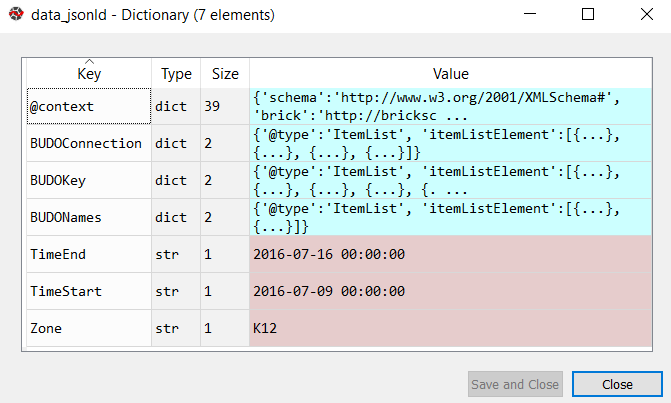